# Package Development Day 1

Joyce Robbins

# What are packages?

- Collections of code

# Where are they stored?

- CRAN
- GitHub
- BioConductor
- Your hard drive

# How to install

- from CRAN:

```r
install.packages("assertthat")
```

```r
install.packages("RLadiesnyc")
```

- from GitHub:

```r
devtools::install_github("jtr13/ggformat")
```

```r
devtools::install_github("jtr13/ggformat", force = TRUE)
```

Many packages are available both on CRAN and GitHub:

“dev version”

```r
devtools::install_github("tidyverse/forcats")
```

- from your hard drive:

```r
devtools::install("~/ggformat")
```

Regardless of the method, the packages are *installed* – see Packages –>

# What is a “source” package?

```r
fs::dir_tree("~/ggformat")
```

```
~/ggformat
├── DESCRIPTION
├── LICENSE
├── NAMESPACE
├── R
│   └── ggformat.R
├── Readme.Rmd
├── Readme.md
├── ggformat.Rproj
├── ggplot2template.png
├── inst
│   └── rstudio
│       └── addins.dcf
├── man
│   └── FormatCode.Rd
└── orderwords.txt
```

```r
list.files("~/ggformat")
```

```
 [1] "DESCRIPTION"         "ggformat.Rproj"      "ggplot2template.png"
 [4] "inst"                "LICENSE"             "man"
 [7] "NAMESPACE"           "orderwords.txt"      "R"
[10] "Readme.md"           "Readme.Rmd"
```

# Why use projects?

So you never have to use `getwd()` or `setwd()` again. You’re always just in the right place.

# Loading vs. installing

Usually we use `library()` to load packages into memory. While developing a package we use `devtools::load_all()`.

- It doesn’t show up in the list of packages (or at least the version under development doesn’t.)
- The functions are in memory and will disappear if we restart R.

# Creating a package

We need some essential files: `DESCRIPTION` and a folder called `R` with `.R` files.

The easier way to create the structure is with `create_package()`:

```r
library(devtools)
create_package("~/covidtime")
```

```
✓ Creating '/Users/joycerobbins/covidtime/'
✓ Setting active project to '/Users/joycerobbins/covidtime'
✓ Creating 'R/'
✓ Writing 'DESCRIPTION'
Package: covidtime
Title: What the Package Does (One Line, Title Case)
Version: 0.0.0.9000
Authors@R (parsed):
    * First Last <first.last@example.com> [aut, cre] (YOUR-ORCID-ID)
Description: What the package does (one paragraph).
License: `use_mit_license()`, `use_gpl3_license()` or friends to
    pick a license
Encoding: UTF-8
Roxygen: list(markdown = TRUE)
RoxygenNote: 7.1.2
✓ Writing 'NAMESPACE'
✓ Writing 'covidtime.Rproj'
✓ Adding '^covidtime\\.Rproj$' to '.Rbuildignore'
✓ Adding '.Rproj.user' to '.gitignore'
✓ Adding '^\\.Rproj\\.user$' to '.Rbuildignore'
✓ Opening '/Users/joycerobbins/covidtime/' in new RStudio session
✓ Setting active project to '<no active project>'
```

# YOUR TURN

See Day1_lab.md

# Using the package in another project / script

Before we can use the package elsewhere we need to:

- add function documentation by clicking “Code… Insert Roxygen Skeleton” (or at a minimum include `@export`)
- edit DESCRIPTION
- document with `devtools::document()`
- install the package with `devtools::install()`

# YOUR TURN

See Day1_lab.md

# Package states

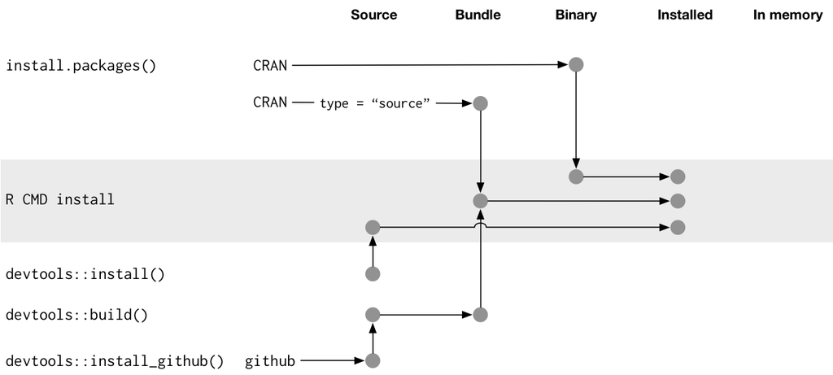

Source: https://r-pkgs.org/package-structure-state.html#installed-package

Key points:

- `devtools::install()`: source –> installed
- `install.packages()`: binary –> installed
- Developers submit *bundles* to CRAN, CRAN builds and distributes *binaries*

# Closer look at package files

DEMO